# Synthèses des outils logiciels

pc

M2 IGAST 2020-2021

Dans la séance de synthèse, 19 étudiant.e.s ont répondu à diverses questions ouvertes sur la plateforme Wooclap dont voici les réponses,illustrées sous la forme de nuages de mots quand c’est possible.

# 1 Liste des outils

Je demandais de lister tous les outils qu’ils avaient utilisé cette année :

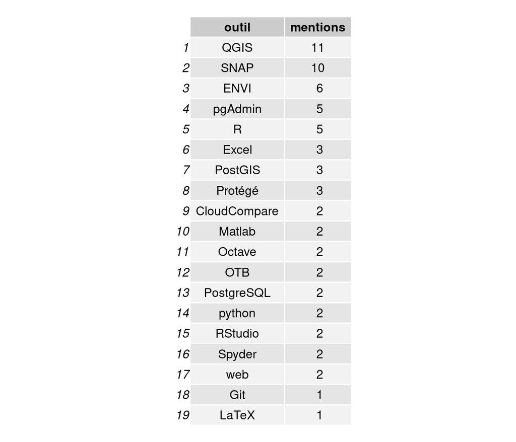

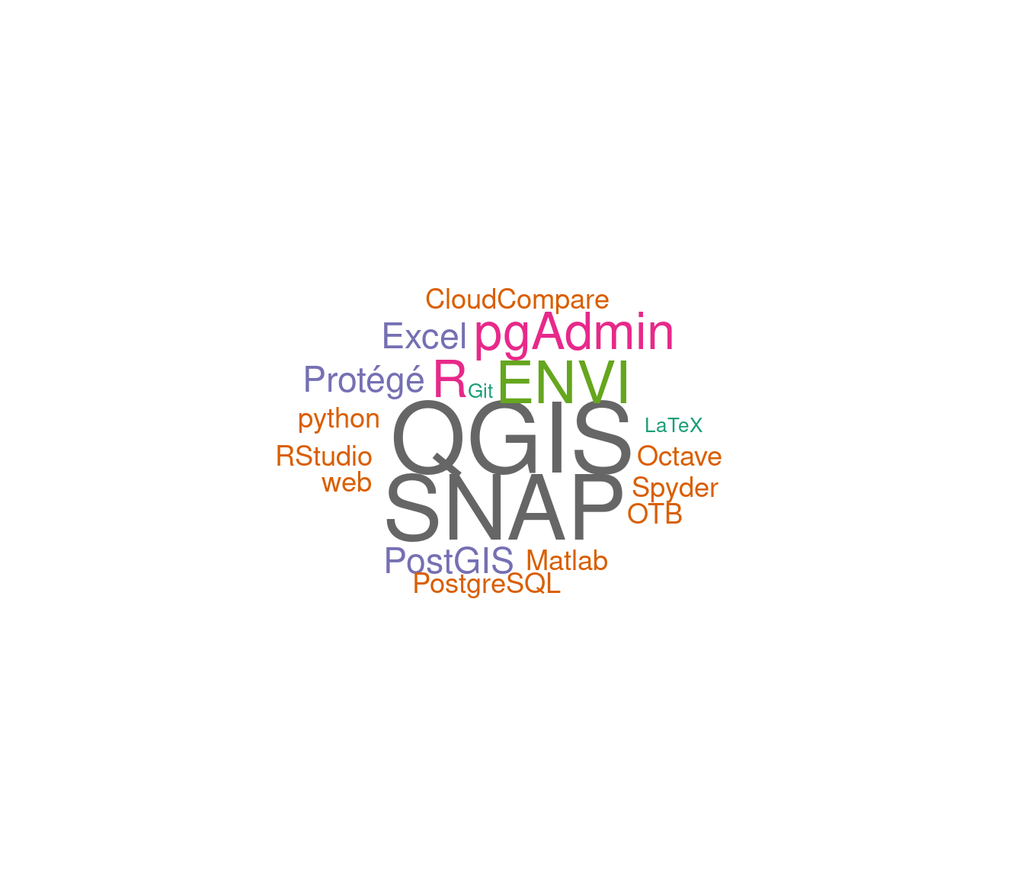

Réponse inattendue : “web”

Matlab est utilisé en parallèle d’Octave, sa version opensource très similaire, pour ceux qui n’ont pas de licence ou qui n’ont pas pu venir à l’ENSG.

Outils que je ne connaissais pas :

- SNAP : logiciel de télédetection developpé par la CNES . traitement d’image radar plus qu’optique ou type Sentinel
- ENVI (propriétaire): logiciel de télédec ,traitements d’images en général , utilisé ici pour classification
- Protégé : solution de gestion d’ontologies utilisé lors du TP d’appariement d’éléments géographiques.
- CLOUD COMPARE : logiciel pour visualiser des nuages de points (LIDAR) par exemple pour faire des teintes isométriques
- OTB (open source ) : suite logicielle pour la télédec

## 1.1 Interprétation perso

Les étudiants distinguent le langage de programmation de l’IDE utilisé pour développer : R et RStudio, python et Spyder. Aucun n’a mentionné d’outil bureautique de “rendu” (traitement de texte, diaporama), à l’exception de LaTeX, mentionné une fois. On pourrait s’attendre à ce que tous mentionnent chaque outil, ce qui est loin d’être le cas. Je m’attendais à voir apparaître python beaucoup plus souvent, de même que certains services ou sites web, du genre OpenStreetMap.

# 2 Critères adéquats pour juger un outil

Comptage des critères importants aux yeux des étudiants concernant les outils. J’ai regroupé les critères similaires sous la même étiquette. Un.e étudiant.e pouvait donner plusieurs critères.

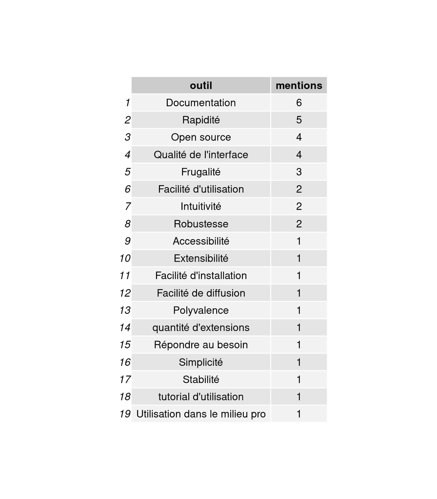

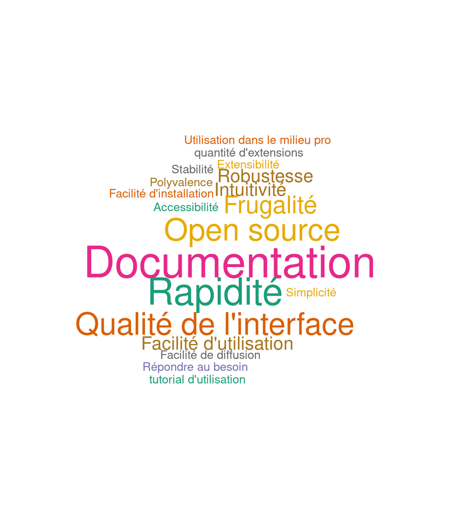

## 2.1 Interprétation perso

Pour comprendre l’écrasante préférence pour les outils avec une belle GUI, j’ai posé la question suivante :

# 3 Pourquoi l’interface graphique est préférée à l’interface console ?

Voici les réponses :

## 3.1 en faveur de la GUI

- *Sur une interface spyder par exemple,tout est bien pensé : script python à gauche,console à droite,liste de variable actuelles,documentation librairies,plot…*
- *facile à manipuler*
- *c’est visible*
- *plus facile à utiliser pour les débutants*
- *permet l’exploration des possibilités liées à notre apprentissage*
- *pas forcément besoin d’aller lire la doc*
- *ergonomiquement plus simple*
- *on a un résultat visuel*
- *facile*
- *on sait exactement quels paramètres appliquer, c’est plus clair*
- *moins abrupte pour un débutant*
- *les logos peuvent être parlants*
- *simple*
- *options discernables*
- *intuitif*

## 3.2 Neutre

- *Pour ma part je n’ai pas de préférence ,les deux ont leurs avantages*

## 3.3 En défaveur

- *Désavantage : la GUI est moins automatisable*

## 3.4 Interprétation perso

La GUI remporte une large adhésion. Je crois que c’est parce qu’en dehors du trio “Qgis-postgis-python”, les outils sont “découverts”, c’est-à-dire abordés pour la première fois et en peu de temps, or pour avoir un aperçu des fonctionnalités d’un outil, une GUI fait mieux l’affaire.

Les étudiant.e.s semblent friand.e.s d’interfaces ergonomiques et esthétiques, pour pouvoir cliquer un peu partout et voir ce que ça fait. Il est vrai que ça évite de lire la documentation, ce qu’ils n’ont sans doute pas le temps de faire. Peut être qu’ils.elles n’ont pas assez eu à faire de traitements massifs et répétitifs pour se rendre compte de la nécessité d’automatiser. J’espère qu’ils en sont au moins convaincus.

# 4 Adéquation outils-tâches

Les tâches que j’ai proposées sont forcément générales et abstraites, pour avoir plusieurs candidats. Je demandais une sélection non ordonnée parmi les outils à disposition.

## 4.1 Meilleurs outils pour afficher des données

Les données peuvent être spatiales ou non.

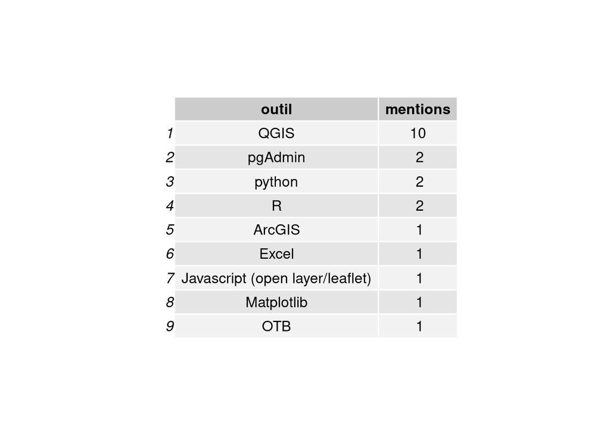

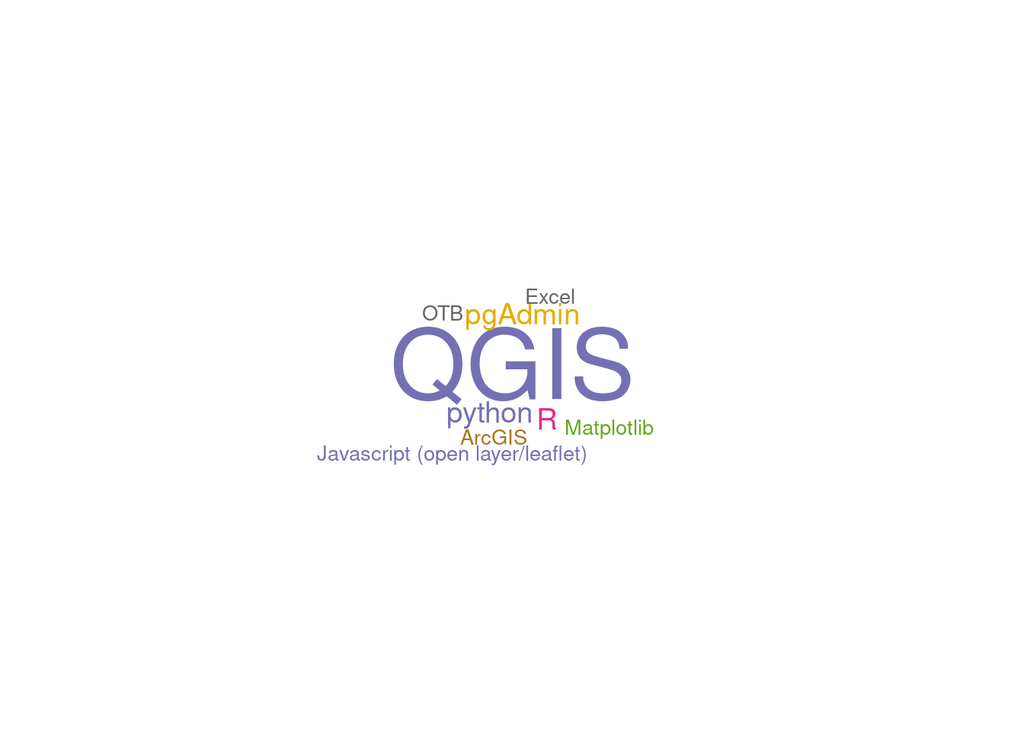

La présence de pgAdmin comme outil de visualisation me laisse perplexe… On remarque aussi la toute petite proportion de web mapping

## 4.2 Meilleurs outils pour importer des données spatiales ou non

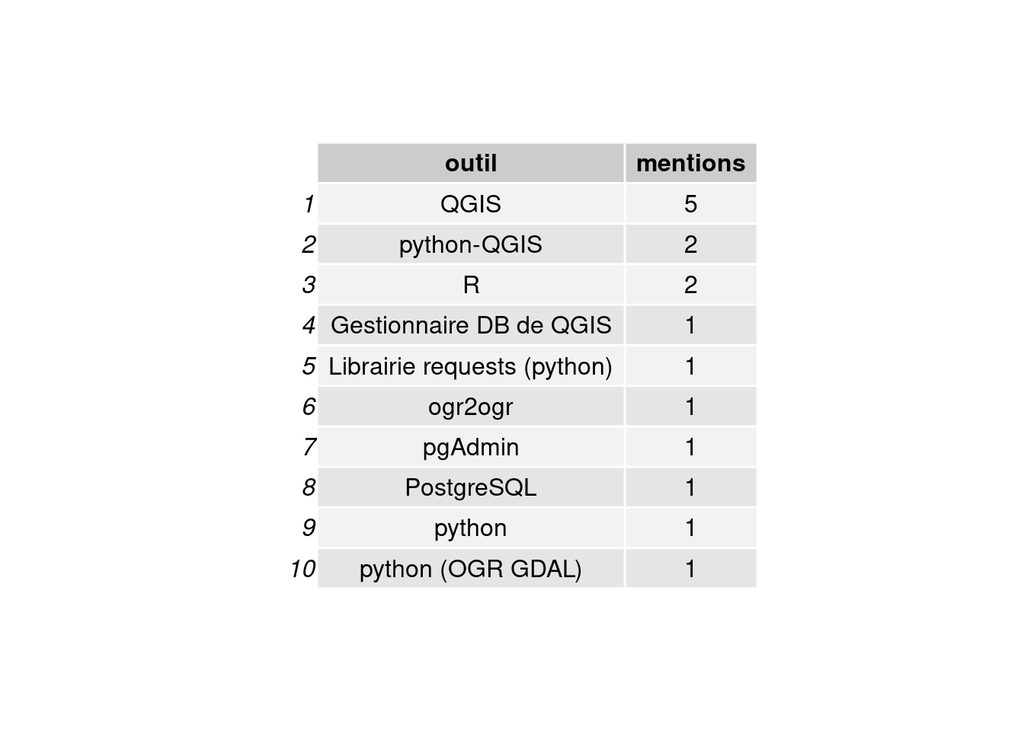

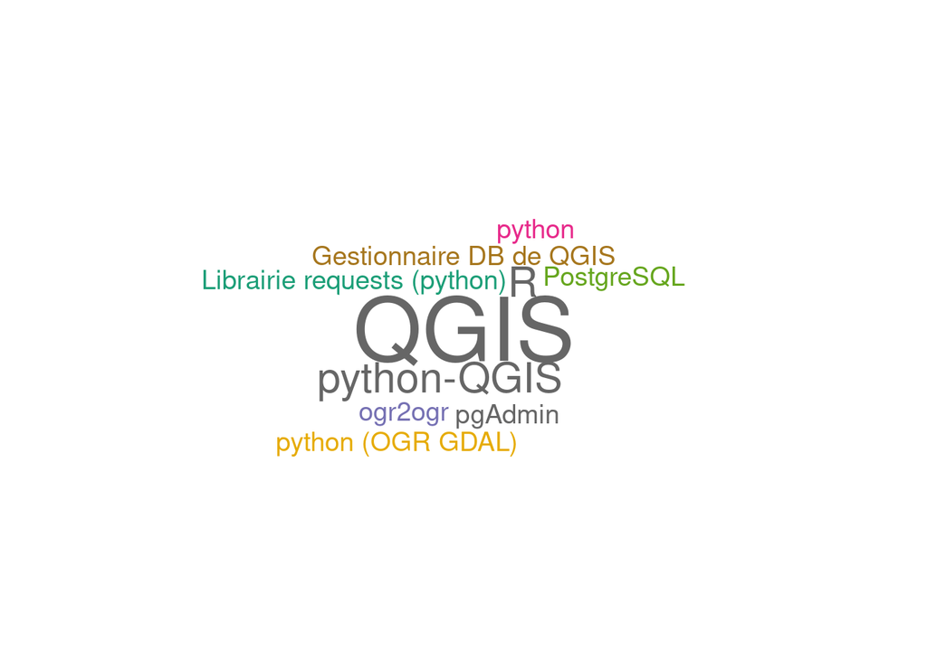

Python revient sous plusieurs formes en cumulé il est à égalité avec QGIS, toujours en tête. Je m’attendais à plus d’outils OGR/GDAL et les scripts outils pour alimenter PostGIS, mais c’est certainement le rôle qu’endosse QGIS ici avec son gestionnaire DB.

## 4.3 Meilleurs outils pour transformer les données spatiales

Transformer ici signifie : changer de format, de projection, ou de nature (par exemple vectoriser des rasters ou rasteriser des données vecteur).

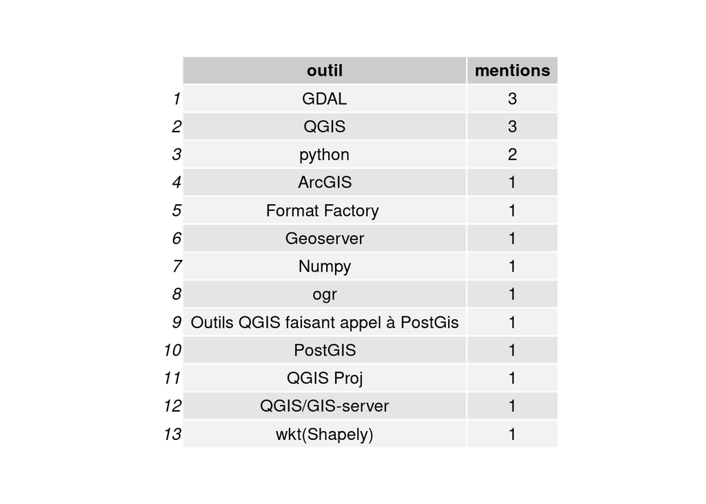

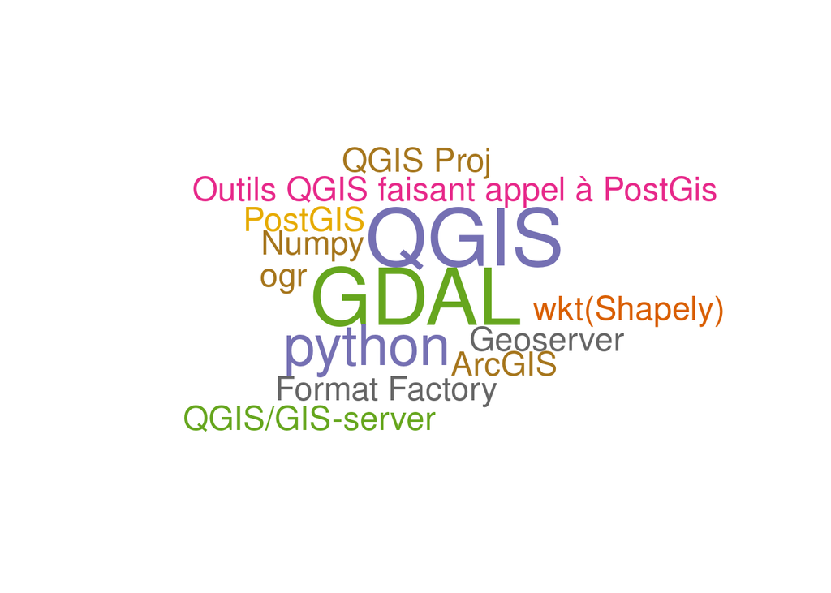

## 4.4 Meilleurs outils pour calculer, mesurer ,enrichir des données :

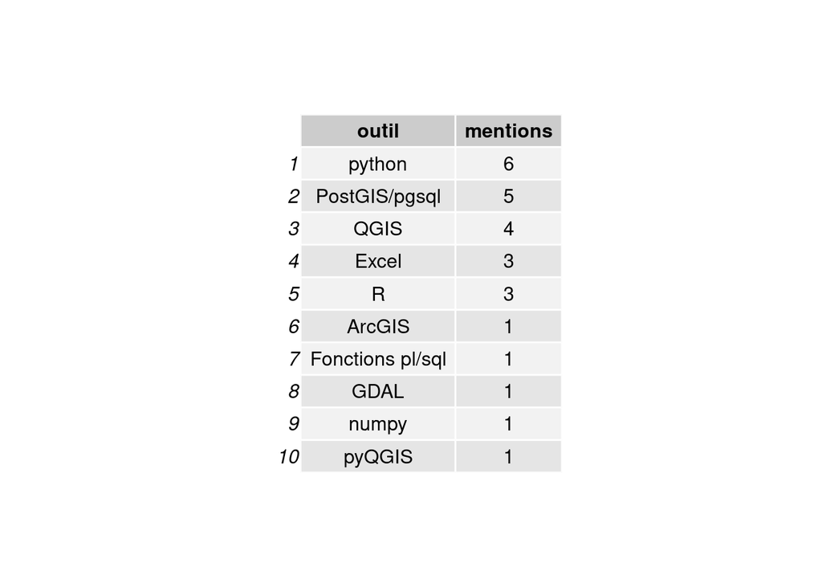

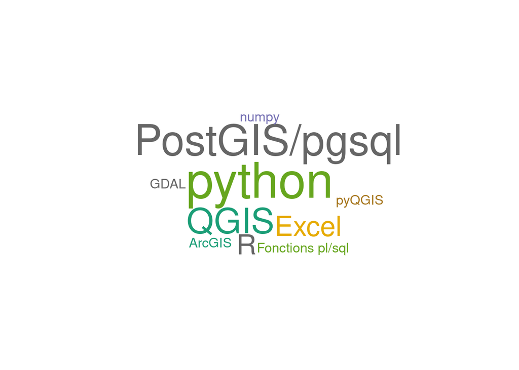

Il est difficile de savoir si les étudiant.e.s distinguent vraiment PostgreSQL de PostGIS, j’ai fusionné les deux.

## 4.5 Meilleurs outils pour exporter et mettre à disposition des données

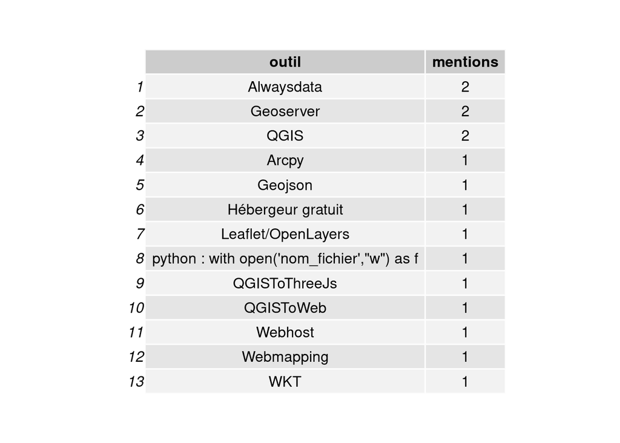

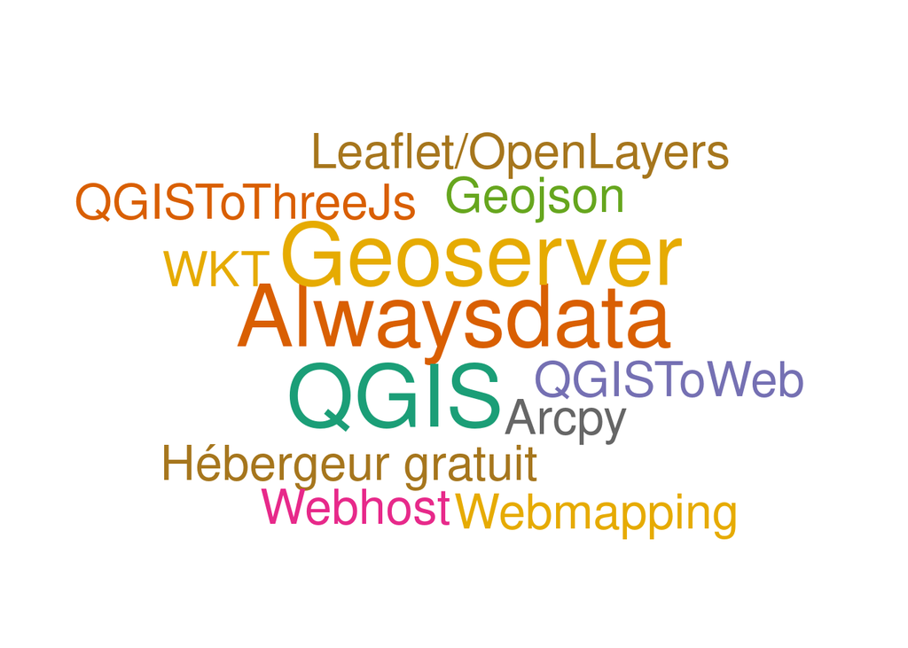

- AlwaysData est un hebergeur gratuit que les étudiant.e.s ont utilisé en cours.

Il y a encore des réponses qui me laissent penser que mes questions n’étaient pas claires où qu’elles n’ont pas été comprises. (WKT qui est un format, l’ouverture de fichier en python pour sauvegarder ???)

# 5 Quelle forme vous paraît la plus adaptée pour représenter les réponses ?

- Diagrammes/infographies
- Faire un fiche avec un tableau. Procéder par tâches.
- agrégation par tâches
- par tâche
- grille d’analyse
- Par fiche c’est sans doute plus pratique
- Carte mentale

# 6 Expression libre des étudiant.e.s

retranscrites telles qu’elles, je souligne les passages qui me semblent importants

> j’ai découvert de nouveaux logiciels et leurs utilisations tels que R ou ENVI /SAGA et je trouve ça vraiment bien car on apprend à être **polyvalent**. Néanmoins,je trouve que **QGIS prend beaucoup de place**, or il serait appréciable de pouvoir faire des TP ou projets sur la suite **ArcGIS** car il est également possible de faire de la **programmation sous SIG**,de la **BDD**, de l’**analyse spatiale**, **IA** ou encore de la **télédétection**.

> Bonne idée de faire un tel cours, permet de se rendre compte de tous les outils dont on dispose. Je pense que c’est une idée à garder pour les prochaines années.

> On ne manipule **pas assez Python** cette année

> Je pense qu’il aurait été plus pertinent d’utiliser **Google Form** pour avoir un feedback plus réaliste

> Continuer d’utiliser **Wooclap** c’est vraiment bien pour le distanciel !